# Phyloseq Analysis

Load the necessary packages

Inspect the phyloseq object

```r
class(ps2)
```

```
[1] "phyloseq"
attr(,"package")
[1] "phyloseq"
```

```r
dna <- Biostrings::DNAStringSet(taxa_names(ps2))
names(dna) <- taxa_names(ps2)
ps2 <- merge_phyloseq(ps2, dna)
taxa_names(ps2) <- paste0("ASV", seq(ntaxa(ps2)))
ps2
```

```
phyloseq-class experiment-level object
otu_table()   OTU Table:         [ 936 taxa and 7 samples ]
sample_data() Sample Data:       [ 7 samples by 10 sample variables ]
tax_table()   Taxonomy Table:    [ 936 taxa by 7 taxonomic ranks ]
phy_tree()    Phylogenetic Tree: [ 936 tips and 934 internal nodes ]
refseq()      DNAStringSet:      [ 936 reference sequences ]
```

```r
pps<-ps2 #save the phyloseq object as pps
```

Explore taxonomic labels

We shall access the data stored in ‘ps’ object. To explore subsections of the data in ps we will use the operator @.

```r
View(pps@tax_table@.Data)
```

Here we can see that the tax_table inside our phyloseq object stores all the taxonomic labels that correspond to each ASV. ASVs are identified by a number in the row names of the table.

Explore how many phyla we have;

```r
unique(pps@tax_table@.Data[,"Phylum"])
```

```
 [1] "Bacteroidota"                 "Proteobacteria"
 [3] "Cyanobacteria"                "Planctomycetota"
 [5] "Actinobacteriota"             "Chloroflexi"
 [7] "Verrucomicrobiota"            "Firmicutes"
 [9] "Gemmatimonadota"              "SAR324 clade(Marine group B)"
[11] "Acidobacteriota"              "Bdellovibrionota"
[13] "Patescibacteria"              "Myxococcota"
[15] "Abditibacteriota"             "Campylobacterota"
```

Check how many ASVs have been assigned to a particular Phylum:

```r
 sum(pps@tax_table@.Data[,"Phylum"] == "Cyanobacteria")
```

```
[1] 16
```

Checking which taxa are in a certain rank of a particular Phylum for instance “Class”.

```r
unique(pps@tax_table@.Data[pps@tax_table@.Data[,"Phylum"] == "Cyanobacteria","Class"])
```

```
[1] "Cyanobacteriia"
```

Explore abundance table

```r
View(pps@otu_table@.Data)
```

Plot Alpha diversity We want to know how is the bacterial diversity, so we will prune all of the non-bacterial organisms that we have in our ps Phyloseq object. To do this we will make a subset of all bacterial groups and save them.

```r
pps <- subset_taxa(pps, Kingdom == "Bacteria")
```

```r
pps
```

```
phyloseq-class experiment-level object
otu_table()   OTU Table:         [ 936 taxa and 7 samples ]
sample_data() Sample Data:       [ 7 samples by 10 sample variables ]
tax_table()   Taxonomy Table:    [ 936 taxa by 7 taxonomic ranks ]
phy_tree()    Phylogenetic Tree: [ 936 tips and 934 internal nodes ]
refseq()      DNAStringSet:      [ 936 reference sequences ]
```

```r
sample_sums(pps)
```

```
   F1    F2    F3    F4    F5    F6    F7
 5025  6110  9604  3881 12386   143 10593
```

```r
summary(pps@otu_table@.Data)
```

[output not shown]

[output cut: 155 more lines]

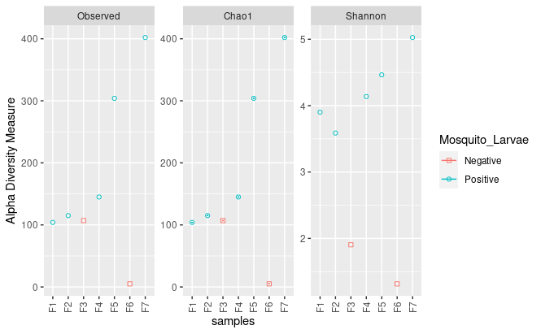

```r
plot_richness(physeq = pps, measures = c("observed", "Chao1", "Shannon"), shape = "Mosquito_Larvae", color = "Mosquito_Larvae") + scale_shape_manual(values = 0:length(unique(sample_metadata$Mosquito_Larvae)))+ theme(axis.text.x=element_text(angle=90,hjust=1))
```

```r
pdf("~/Desktop/PacBio/Figures/a-diversity.pdf",
    width = 12,
    height = 8,
    pointsize = 8)
plot_richness(physeq = pps, measures = c("observed", "Chao1", "Shannon"), shape = "Mosquito_Larvae", color = "Mosquito_Larvae") + scale_shape_manual(values = 0:length(unique(sample_metadata$Mosquito_Larvae)))+ theme(axis.text.x=element_text(angle=90,hjust=1))
```

Each of these metrics can give an insight into the distribution of the OTUs inside our samples. For example, the Chao1 diversity index gives more weight to singletons and doubletons observed in our samples, while Shannon is an entropy index remarking the impossibility of taking two reads out of the metagenome “bag” and that these two will belong to the same OTU.

Absolute and relative abundance

```r
summary(pps@tax_table@.Data== "NA")
```

[output not shown]

```r
pps<- subset_taxa(pps, Genus !="NA")
summary(pps@tax_table@.Data== "NA")
```

```
  Kingdom          Phylum          Class           Order           Family          Genus          Species
 Mode :logical   Mode :logical   Mode :logical   Mode :logical   Mode :logical   Mode :logical   Mode :logical
 FALSE:689       FALSE:689       FALSE:689       FALSE:689       FALSE:689       FALSE:689       FALSE:13
                                                                                                 NA's :676
```

```r
head(ps@otu_table@.Data)
```

[output not shown]

[output cut: 31 more lines]

Transform to percentages

```r
percentages <- transform_sample_counts(pps, function(x) x*100 / sum(x))
```

```r
head(percentages@otu_table@.Data)
```

Beta diversity

Beta diversity is a measure of how alike or different are our samples (overlap between discretely defined sets of species or operational taxonomic units). In order to measure this, we need to calculate an index that suits the objectives of our research. By the next code, we can display all the possible distance metrics that Phyloseq can use:

```r
distanceMethodList
```

```
$UniFrac
[1] "unifrac"  "wunifrac"

$DPCoA
[1] "dpcoa"

$JSD
[1] "jsd"

$vegdist
 [1] "manhattan"  "euclidean"  "canberra"   "bray"       "kulczynski" "jaccard"    "gower"      "altGower"   "morisita"   "horn"       "mountford"  "raup"
[13] "binomial"   "chao"       "cao"

$betadiver
 [1] "w"   "-1"  "c"   "wb"  "r"   "I"   "e"   "t"   "me"  "j"   "sor" "m"   "-2"  "co"  "cc"  "g"   "-3"  "l"   "19"  "hk"  "rlb" "sim" "gl"  "z"

$dist
[1] "maximum"   "binary"    "minkowski"

$designdist
[1] "ANY"
```

```r
meta_ord <- ordinate(physeq = percentages, method = "PCoA", distance = "wunifrac")
```

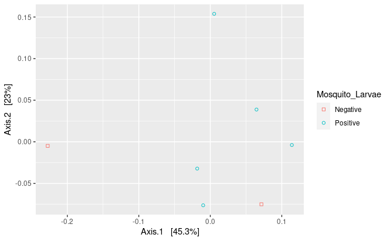

```r
plot_ordination(physeq=percentages, ordination = meta_ord, color = "Mosquito_Larvae", shape= "Mosquito_Larvae") + scale_shape_manual(values = 0:length(unique(sample_metadata$Mosquito_Larvae)))
```

```r
pdf("~/Desktop/PacBio/Figures/beta_diversity_wunifrac.pdf",
    width = 12,
    height = 8,
    pointsize = 8)
plot_ordination(physeq=percentages, ordination = meta_ord, color = "Mosquito_Larvae", shape= "Mosquito_Larvae") + scale_shape_manual(values = 0:length(unique(sample_metadata$Mosquito_Larvae)))
```

We will start our exploration at the Phylum level. In order to group all the OTUs that have the same taxonomy at a certain taxonomic rank, we will use the function tax_glom().

```r
percentages_glom <- tax_glom(percentages, taxrank = 'Phylum')
View(percentages_glom@tax_table@.Data)
```

Another phyloseq function is psmelt(), which melts phyloseq objects into a data.frame to manipulate them with packages like ggplot2 and vegan.

```r
percentages_df <- psmelt(percentages_glom)
str(percentages_df)
```

```
'data.frame':   98 obs. of  15 variables:
 $ OTU             : chr  "ASV1" "ASV2" "ASV2" "ASV2" ...
 $ Sample          : chr  "F3" "F5" "F6" "F7" ...
 $ Abundance       : num  77.5 74.8 70.9 66.5 56.5 ...
 $ Mosquito_Larvae : chr  "Negative" "Positive" "Negative" "Positive" ...
 $ Temperature     : num  32.2 32.7 30.6 31.1 33.5 31.4 31.4 33.5 32.6 32.6 ...
 $ pH              : num  8.1 8.56 8.51 8.47 8.69 7.87 7.87 8.69 8.97 8.97 ...
 $ Dissolved_Oxygen: num  7.06 4.08 5.1 7.73 8.68 5.21 5.21 8.68 3.95 3.95 ...
 $ Salinity        : num  0.1 0.26 2.34 0.04 0.82 1.26 1.26 0.82 0.48 0.48 ...
 $ Nitrate         : num  29.3 26 18.3 24.8 24.2 23.6 23.6 24.2 19.2 19.2 ...
 $ Nitrite         : num  4.9 4.4 2.9 5.5 6.8 3.2 3.2 6.8 3.02 3.02 ...
 $ Ammonia         : num  11.8 9.7 13.6 12.6 24.6 12.2 12.2 24.6 7.2 7.2 ...
 $ Phosphate       : num  3.7 2.4 1.66 3.3 6.9 3.8 3.8 6.9 3.6 3.6 ...
 $ Site            : chr  "F3" "F5" "F6" "F7" ...
 $ Kingdom         : chr  "Bacteria" "Bacteria" "Bacteria" "Bacteria" ...
 $ Phylum          : chr  "Bacteroidota" "Proteobacteria" "Proteobacteria" "Proteobacteria" ...
```

```r
absolute_glom <- tax_glom(physeq = ps, taxrank = "Phylum")
absolute_df <- psmelt(absolute_glom)
str(absolute_df)
```

```
'data.frame':   112 obs. of  15 variables:
 $ OTU             : chr  "ASV2" "ASV1" "ASV2" "ASV2" ...
 $ Sample          : chr  "F5" "F3" "F7" "F2" ...
 $ Abundance       : num  8200 7238 5753 3401 2604 ...
 $ Mosquito_Larvae : chr  "Positive" "Negative" "Positive" "Positive" ...
 $ Temperature     : num  32.7 32.2 31.1 33.5 31.4 33.5 31.1 31.4 31.1 32.2 ...
 $ pH              : num  8.56 8.1 8.47 8.69 7.87 8.69 8.47 7.87 8.47 8.1 ...
 $ Dissolved_Oxygen: num  4.08 7.06 7.73 8.68 5.21 8.68 7.73 5.21 7.73 7.06 ...
 $ Salinity        : num  0.26 0.1 0.04 0.82 1.26 0.82 0.04 1.26 0.04 0.1 ...
 $ Nitrate         : num  26 29.3 24.8 24.2 23.6 24.2 24.8 23.6 24.8 29.3 ...
 $ Nitrite         : num  4.4 4.9 5.5 6.8 3.2 6.8 5.5 3.2 5.5 4.9 ...
 $ Ammonia         : num  9.7 11.8 12.6 24.6 12.2 24.6 12.6 12.2 12.6 11.8 ...
 $ Phosphate       : num  2.4 3.7 3.3 6.9 3.8 6.9 3.3 3.8 3.3 3.7 ...
 $ Site            : chr  "F5" "F3" "F7" "F2" ...
 $ Kingdom         : chr  "Bacteria" "Bacteria" "Bacteria" "Bacteria" ...
 $ Phylum          : chr  "Proteobacteria" "Bacteroidota" "Proteobacteria" "Proteobacteria" ...
```

With these objects and what we have learned regarding R data structures and ggplot2, we can proceed to compare them with a plot. First, let’s take some steps that will allow us to personalize our plot making it accessible for color-blindness. We will create a color palette. With colorRampPalette we will choose 8 colors from the Dark2 palette and make a “ramp” with it, that is, convert those 8 colors to the number of colors needed to have one for each phylum in our data frame. For this we need to have our Phylum column in the factor structure.

```r
absolute_df$Phylum <- as.factor(absolute_df$Phylum)
phylum_colors_abs<- colorRampPalette(brewer.pal(8,"Dark2")) (length(levels(absolute_df$Phylum)))
```

Now, let´s create the figure for the data with absolute abundances (i.e absolute_plot object)

```r
absolute_plot <- ggplot(data= absolute_df, aes(x=Sample, y=Abundance, fill=Phylum))+
    geom_bar(aes(), stat="identity", position="stack")+
    scale_fill_manual(values = phylum_colors_abs)+theme_classic()+ theme(axis.text.x = element_text(angle = 90, hjust = 1))+ facet_wrap(~Mosquito_Larvae, scales="free_x")
```

With the position=“stack” command, we are telling the ggplot function that the values must stack each other for each of the samples. In this way, we will have all of our different categories (OTUs) stacked in one bar and not each in a separate one. For more info position_stack

Next, we will create the figure for the representation of the relative abundance data, and ask RStudio to show us both plots thanks to the | function from the library patchwork:

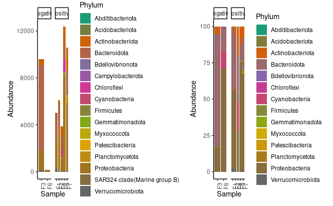

```r
percentages_df$Phylum <- as.factor(percentages_df$Phylum)
phylum_colors_rel<- colorRampPalette(brewer.pal(8,"Dark2")) (length(levels(percentages_df$Phylum)))
relative_plot <- ggplot(data=percentages_df, aes(x=Sample, y=Abundance, fill=Phylum))+
    geom_bar(aes(), stat="identity", position="stack")+
    scale_fill_manual(values = phylum_colors_rel)+ theme_classic()+ theme(axis.text.x = element_text(angle = 90, hjust = 1))+ facet_wrap(~Mosquito_Larvae, scales="free_x")
absolute_plot | relative_plot
```

```r
pdf("~/Desktop/PacBio/Figures/Abundance-Rel_barplot.pdf",
    width = 12,
    height = 8,
    pointsize = 8)
absolute_plot | relative_plot
```

Relative plot

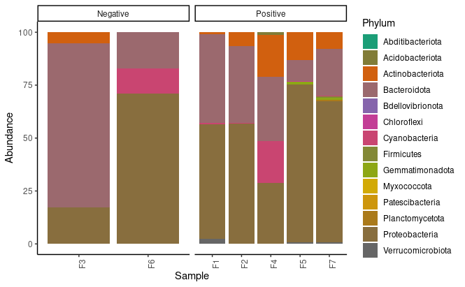

```r
relative_plot
```

save PDF

```r
pdf("~/Desktop/PacBio/Figures/Phylum-Rel_barplot2.pdf",
    width = 12,
    height = 8,
    pointsize = 12)
relative_plot
```

extract a specific phylum from our data, and explore it at a lower taxonomic level:

```r
cyanos <- subset_taxa(pps, Phylum == "Cyanobacteria")
unique(cyanos@tax_table@.Data[,2])
```

```r
cyanos_percentages <- transform_sample_counts(cyanos, function(x) x*100 / sum(x))
cyanos_glom <- tax_glom(cyanos_percentages, taxrank = "Genus")
cyanos_df <- psmelt(cyanos_glom)
cyanos_df$Genus[cyanos_df$Abundance < 10] <- "Genera < 10.0 abund"
cyanos_df$Genus <- as.factor(cyanos_df$Genus)
genus_colors_cyanos<- colorRampPalette(brewer.pal(8,"Dark2")) (length(levels(cyanos_df$Genus)))
plot_cyanos <- ggplot(data=cyanos_df, aes(x=Sample, y=Abundance, fill=Genus))+
    geom_bar(aes(), stat="identity", position="stack")+
    scale_fill_manual(values = genus_colors_cyanos)
plot_cyanos
```

[output not shown]

########Heatmap Plot###########3

```r
theme_set(theme_bw())
```

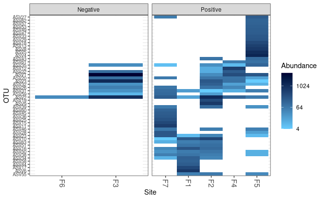

```r
plot_heatmap(gpt, sample.label="Site", low="#66CCFF", high="#000033", na.value="white")+ facet_wrap(~Mosquito_Larvae, scales="free_x")
```

```r
pdf("~/Desktop/PacBio/Figures/top50_asv_heatmap.pdf",
    width = 12,
    height = 8,
    pointsize = 8)
plot_heatmap(gpt, sample.label="Site", low="#66CCFF", high="#000033", na.value="white")+ facet_wrap(~Mosquito_Larvae, scales="free_x")
```

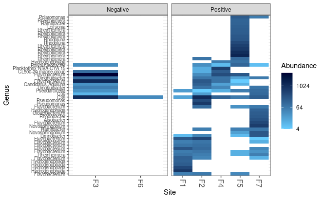

```r
(p <- plot_heatmap(gpt, "NMDS", "bray", "Site", "Genus", low="#66CCFF", high="#000033", na.value="white", sample.order = "Site")+ facet_wrap(~Mosquito_Larvae, scales="free_x"))
```

```r
pdf("~/Desktop/PacBio/Figures/top50_Genus_heatmap.pdf",
    width = 12,
    height = 8,
    pointsize = 8)
(p <- plot_heatmap(gpt, "NMDS", "bray", "Site", "Genus", low="#66CCFF", high="#000033", na.value="white", sample.order = "Site")+ facet_wrap(~Mosquito_Larvae, scales="free_x"))
```

#######Tree######

```r
plot_tree(pps, color="Phylum",shape = "Mosquito_Larvae", ladderize="left")
```

[output not shown]

```r
pdf("~/Desktop/PacBio/Figures/tree-phylum.pdf",
    width = 12,
    height = 8,
    pointsize = 8)
plot_tree(pps, color="Phylum",shape = "Mosquito_Larvae", ladderize="left")
```